# Ethnobotanical classification

Bethwyn Evans

## 1. Introduction

This chapter examines the ways in which Proto Oceanic (POc) speakers classified their knowledge of plants through the reconstruction of semantic categories and their associated labels for higher-order taxa and the hierarchical taxonomies they imply. Five POc terms (*kayu ‘tree, shrub’, *waroc ‘vine’, *pali[s,j]i ‘grass’, *taliŋa ‘mushroom’ and *limut or *lumut ‘moss, algae’) are clearly reconstructable based on reflexes in a wide range of Oceanic languages, but the semantic scope of these terms and other possible higher-order taxa that denote types of plants not encompassed by these five taxa are more difficult to reconstruct.[^1]

## 2. Ethnobiological classifications

It seems to be a human universal to classify flora and fauna into what can be described as hierarchies of labelled taxa. For example, in Wayan Fijian *bau leke* (dwarf *bau*), the name for *Planchonella garberi*, a tree that grows in mid-altitude forests, is one of four kinds of *bau*, the generic term that refers to the *Burckella*, *Manilkara*, *Palaquium* and *Planchonella* species of the Sapotaceae family, woody trees used for making boats, chests and house posts. In turn *bau* is one of 200 or more kinds of *kai*, the generic name for trees and shrubs (Pawley & Sayaba 2003). Thus *kai*, *bau* and *bau leke* form part of a hierarchy of decreasing inclusiveness of botanical terms in Wayan Fijian, schematised in Figure 3.1, and shown in more detail in Figure 3.2 below.

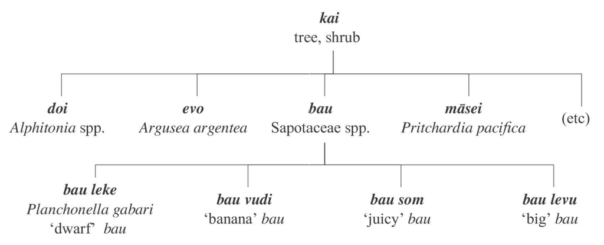

**Figure 3.1:** The hierarchical structure of ethnobiological classifications, exemplified by Wayan Fijian

Not only is the hierarchical classification of flora and fauna an apparent human universal, but the striking similarities in ethnobiological taxonomies across different societies from different parts of the world suggest the presence of universal or general principles of ethnobiological classification. Berlin (1992) argues that these general principles have a cognitive explanation. He proposes that within the biological reality of a local habitat there are readily definable ‘chunks’ that are recognised within folk taxonomies. That is, ethnobiological taxonomies result from the human ability to recognise the single pattern of morphological similarities within a local flora and fauna that stands out from all other patterns (Berlin 1992: 9, 13). Others, such as Diamond (1966) and Hunn (1982), argue that ethnobiological classifications are more culturally specific and based on utilitarian principles. Perhaps more realistically, Hays (1982: 93) proposes that ethnobiological classifications are ‘products of a number of complex interacting factors: biological discontinuities in nature, chance historical events, ’utilitarian’ human concerns, human cultural concerns in a broader sense, intellectual curiosity, and constraints deriving from the nature of human perception and cognition’.

One of the general principles of folk taxonomies proposed by Berlin et al. (1973), and revised in Berlin (1992), is that they all comprise taxa distributed across no more than six mutually exclusive ranks, such that the taxa within each rank show certain similarities to each other and are separate from other taxa within the rank by perceptual gaps. The six ranks, in order of decreasing inclusiveness are: kingdom, life-form, intermediate, generic, specific and varietal, and it is often the case that only the life-form, generic and specific ranks within a taxonomy will be named.

Kingdom is a unique primary taxon, a single taxon that incorporates all taxa of lesser rank. In terms of ethnobotanical classification such a category will tend to correspond to the biological taxon plantae; the English term *plant*, in its broad sense. Life-form taxa are not included in any taxa other than that of the kingdom and mark a small number of types (between 5 and 10) based on the recognition of distinctive morphological structure. English *tree*, *grass* and *vine* are life-form taxa. Folk generics will comprise the largest number of taxa within a system, with some communities distinguishing as many as 500 to 600 generics. The total will depend on how closely the community interacts with their plant environment and on how rich the flora is in the region. These taxa denote categories that are considered distinct on the basis of their shared morphological structure and ecological behaviour. The majority of taxa within the generic rank are monotypic and form the lowest level within the classification, and although most folk generics are included within a life-form rank, some are unaffiliated, usually because of their morphological uniqueness or sometimes their economic significance. Taxa of the specific rank are directly subordinate to the folk generics and are usually few in number. Berlin (1992: 24) suggests that subgeneric taxa are in part motivated by cultural considerations, and tend to refer mainly to domesticated plants and animals.

Berlin (1992: 26-35) also argues that there are cross-cultural similarities in the ways in which the taxa of each rank within a taxonomy are named. The kingdom rank, which Berlin implies is a generally recognised one, will often be an implicit category without an overt label.[^2] If labelled it will often be with terms that are polysemous with some subordinate rank. Life-form taxa are generally labelled by non-compound lexical units, although as with the kingdom rank, they are sometimes covert (non-labelled) taxa. Folk generics are also labelled by non-compound lexical units, in contrast to the subordinate specific rank which tends to have compound labels. Berlin (1992: 29-30) notes two conditions under which taxa below the level of folk generic may be labelled by non-compound lexical units. The first is when one taxon of a folk generic is considered to be the prototype of the generic taxon, in which case a primary name may be polysemous denoting both the generic and subgeneric taxa. Taxa below the folk generic level may also be labelled with a primary name if they represent a plant or animal of major cultural importance .

These typical naming strategies can be demonstrated by the Wayan terms in Figure 3.1. The taxa *kai* ‘tree, shrub’ and *bau* ‘Sapotacae species’, apparently life-form and generic taxa respectively, are labelled by non-compound lexical units, whereas the specific rank, for example *bau leke* ‘*Planchonella garberi*’, is labelled by a compound that incorporates the term for the folk generic. As expected the kingdom level taxon in Wayan is not overtly labelled, although *kai* ‘tree, shrub’ is sometimes used to refer to all plants, most commonly in phrasal expressions, such as *vuniwai ni kai* ‘a doctor (i.e. scholar) of trees/plants, botanist’ (Gardner & Pawley 1992: 9). Wayan Fijian *uvi* is a non-compound term that labels a taxon below the level of the folk generic. Most specifically *uvi* denotes a particular type of cultivated yam, *Dioscorea alata*. However, as the most prestigious cultivar, this label also denotes the more general taxon that encompasses the various species of *Dioscorea* (Gardner & Pawley 1992: 12, 14).

There are a number of ways in which the above description of ethnobiological taxonomies is too simplistic. Gardner & Pawley (1992), for example, note a number of problems with assigning taxa within the Wayan Fijian folk classification of plants to ranks within Berlin’s (1992) model. As mentioned Wayan *kai* ‘tree, shrub’ can be treated as a life-form category; it denotes a highly distinctive morphotype, incorporates a large number of taxa of a lesser rank, which are apparent folk generics with primary names, and it is named by a primary (non-compound) lexeme. Wayan *kai* ‘tree, shrub’ contrasts with two other major categories *ō* ‘grass’ and *wā* ‘vine’. However, these two taxa behave somewhat differently from *kai*, raising questions about the notion that they are of equivalent status within the system of classification. While *ō* ‘grass’ and *wā* ‘vine’ denote highly distinctive morphotypes and incorporate a reasonably large number of lesser ranked and heterogeneous taxa, sub taxa of these categories often have binominal labels that include the generic labels *ō* and *wā* (see §3). Although Gardner & Pawley (1992: 13) conclude that *ō* ‘grass’ and *wā* ‘vine’ can be analysed as equivalent ranks to *kai* ‘tree, shrub’, it is important to note that not all taxa representing the same rank within a taxonomy will behave in the same way.

Hunn (1982: 836), on the other hand, argues that the notion of taxonomic rank is ‘a purely formal distinction imposed by the analyst’ and questions whether a taxonomic hierarchy model is an appropriate way to describe and explain ethnobiological classification systems. He presents a number of arguments against a model of folk biological classification based on categories distinguished by general morphological characteristics and in favour of one based more on the practical significance of the classification within the culture. Hunn presents data that point to a cultural basis for life-form taxa in a number of languages. For example, in Sahaptin (Columbia Plateau, United States) the boundaries of the taxa *c’ic’k* ‘grass’ and *latít* ‘flower’ are best defined in terms of cultural practices rather than morphological characteristics alone. So *c’ic’k* ‘grass’ encompasses all herbaceous plants (which are not *latit* ‘flowers’) that are not otherwise named. All such named plants are considered useful in some way, and so plants encompassed by *c’ic’k* ‘grass’ (or *latit* ‘flower’) are defined as non-useful and are grouped together ‘only by virtue of having been passed over in the process of cultural recognition’ (Hunn 1982: 834-5, 838). Thus Sahaptin *c’ic’k* ‘grass’ and *latit* ‘flower’ are residual categories, a notion which is problematic within Berlin’s 1992 model of taxonomic ranks.

Speakers of a language may also have more than one way of classifying plants. The Wayan taxonomy described in most detail by Gardner & Pawley (1992) is one that conforms to Berlin’s model of folk taxonomies based on general biological criteria. It is a taxonomy which at each level recognises a number of apparently mutually exclusive categories based primarily on morphological and ecological features. However, they also note the presence of a second system of classification, based mainly on the uses and cultural status of plants, which comprises categories that cut across those of the other taxonomy (Gardner & Pawley 1992: 15, see also §3 for more details of the Wayan classification of plants). Randall (1976) demonstrates the presence of apparently contradictory categories in folk taxonomies in both English and Samal, a language of the Philippines. Following the expected hierarchy of increasing inclusiveness, in Samal *sagbot tahik* ‘seaweed’ is classified as a type of *sagbot* ‘non-woody vegetation’, which in turn is a category of *tumbutumbuhan* ‘vegetation’ which is a taxon of *isi gumi* ‘flesh of the land’. But *sagbot tahik* ‘seaweed’ is not actually a kind of land flesh (Randall 1976: 546-547). Kwa’ioloa & Burt (2001), on the other hand, describe the higher levels of the ethnobotanical taxonomy of Kwara’ae (SE Solomonic) as a continuum such that particular labelled folk generics or species may be referred to by different higher level taxa under different circumstances.

Hays (1976) goes further and notes that individual speakers of a language will not all have the same knowledge and classification of plants, thus questioning what the description of a folk taxonomy is really representing. Is it a description of a taxonomy comprising the elements that are shared by the majority of speakers? Or a taxonomy comprising the combination of elements from the majority of speakers? Hays demonstrates how amongst the Ndumba speakers of the New Guinea Highlands the knowledge of plant names and classification is variably distributed. Hays has recorded 1,247 plant names in Ndumba, but only 970 items or 77.8% were known to all ten speakers within his sample. However, both these figures are misleading in terms of the number of plant names known by individual speakers, which are less than the combined lexicon of 1,247 and greater than the shared lexicon of 970 items (Hays 1976: 493-494). Interestingly, Hays found that the variation in individuals’ taxonomic models occurred in the middle of the hierarchy with the folk generic and species ranks, while all speakers agreed on life-form and varietal ranks.

Nevertheless the following descriptions of ethnobotanical classifications in modern Oceanic languages are presented within Berlin’s (1992) model, as it provides a clear and consistent way of presenting such classifications cross-linguistically. Also for the majority of Oceanic languages the data is not available to me to present more realistic classifications based on the range offactors noted by Hays (1982) as relevant, including the utilitarian factors described by Hunn (1982). The folk classification of plants for five Oceanic languages, Wayan Fijian, Kwara’ae (SE Solomonic), Nduke (Meso-Melanesian), Arosi (SE Solomonic) and Samoan (Polynesian), are described below. Gardner & Pawley (1992) present the classification of plants in Wayan following Berlin’s model and this description is closely followed in the account of Wayan given below. For the other languages, however, the description of a folk classification of plants within Berlin’s model is a reinterpretation of data presented in other sources. Kwa’ioloa & Burt (2001), a detailed catalogue of plant names and their uses, also presents information on the traditional Kwara’ae classification system which is described here in terms of the ranks within Berlin’s model. For Nduke, Arosi and Samoan the data on ethnobotanical categories has been collated from dictionaries (Scales n.d., Fox 1978 and Milner 1966, respectively) and thus the reinterpretation of the data within Berlin’s model entailed not only decisions on the rank of particular terms, but also on the hierarchy itself and the inclusiveness of particular lexemes.

In line with Hays’ (1982: 93) range of explanations for folk taxonomies, the similar types of categories found within ethnobotanical classifications in Oceanic languages are unsurprising for a number of reasons. First, many features of the botanical classifications in Oceanic languages are those that would be predicted on the basis of what Berlin (1992) proposes as universal tendencies. For example, the life-form taxa of many Oceanic languages distinguish between woody plants, climbing or creeping plants and grass-like plants, morphological characteristics that form the basis of life-form taxa in many folk taxonomies (see also Brown 1984). Further, since Oceanic languages are spoken within regions having more or less similar flora and fauna, it is not unexpected that more specific details of ethnobotanical classifications would be similar across Oceanic languages. Traditional Oceanic societies also share similar foraging-horticultural lifestyles, and thus certain utilitarian aspects of botanical folk taxonomies would also be expected to be similar. And finally, since all Oceanic languages are related, their systems of ethnobotanical classification might be expected to be similar because they have a common origin. Cognate lexical labels across modern Oceanic languages provide evidence for the common origin of certain taxa, and their reconstruction for POc.

Pawley (2000) describes differences in the stability of terms denoting different types of taxa within ethnobiological classifications of Oceanic languages. He finds that the modifying terms in binomial names for folk specifics are much less stable than the terms for folk generics, and suggests that one explanation for this is that species show a wide range of distinctive morphological and ecological characteristics from which one is picked out and named by the modifier in a binomial label, and such modifiers are liable to be replaced by competing labels (Pawley 2000:37). Higher-order generics (for example, life-form taxa) tend to be just as stable in form as folk generics, but less stable in meaning. The reason for this, Pawley (2000: 37) suggests, is that these higher-order taxa form much less homogeneous categories than lower-order taxa. They tend to consist of a disparate class of animals or plants which are linked by relatively few distingushing characteristics, a situation which allows speakers to extend or contract the boundaries of the class for certain purposes more easily. This can be seen particularly with the descriptions of Kwara’ae *ʔai* and Wayan *ō* below which have both broad and narrow conventionalised meanings.[^3] It is important to note that here, perhaps more that in other semantic domains, the reconstructions represent only a part of the original system and project a uniformity that is most likely unrealistic in a number of respects.

Pawley (2000: 3-4) proposes that detailed reconstructions of lexical semantics are best made using what can be called the ‘terminological method of reconstruction’. Thus hypotheses about the meanings of reconstructed lexical items are made within a particular semantic field and with reference to semantic relationships between terms within a semantic domain on the basis of the semantic field in modern Oceanic languages (see also Ross et al. 1998: 4-6). In accord with the terminological method the following section examines the ethnobotanical classifications found in a number of modern languages as a preliminary to reconstructing botanical life-form taxa for POc. Section 4 presents cognate sets which suggest the reconstruction of terms expected to have ocurred in POc. The meanings of the POc etyma reconstructed are based on both the meanings of the reflexes in daughter languages and on the apparent contrasts within the POc systems of ethnobotanical classification.

## 3. Botanical taxonomies in modern Oceanic languages

Comparison of ethnobotanical classifications across modern Oceanic languages is rather difficult since there are few detailed descriptions of such systems. Nonetheless, from the descriptions I’ve found and from dictionary searches it can be seen that a number of Oceanic societies have similar, though by no means identical, types of ethnobotanical taxonomies.

### 3.1. Wayan Fijian

One of the better described Oceanic systems of ethnobotanical classification is that of Wayan Fijian, as presented in Gardner & Pawley (1992) and Pawley & Sayaba (2003). Figure 3.2 shows schematically the major parts of the higher order botanical taxa in Wayan Fijian.

As in many Oceanic languages, in Wayan there is no single lexical item that conventionally denotes all plants in contrast to non-plants. Rather this is a covert category which is occasionally overtly expressed through the extension of the terms *kai* or *ō*, which primarily denote life-form categories (Gardner & Pawley 1992: 8-9). When used in a broad sense *ō* denotes all leafy plants including bamboos, trees, reeds and vines, but does not include mosses, lichens and mushrooms. Wayan Fijian has general terms *taliŋa* ‘generic, includes various kinds of fungi, eg. mushrooms, bracket fungi’ and *lumelume* ‘algae, green slime which grows on reefs and keels of boats, and in rivers and ponds’. However, there is no evidence in Wayan for a taxon that is higher than the broad uses of *kai* and *ō* which would encompass ‘leafy plants’ as well as fungi, mosses and lichens (Andrew Pawley pers. comm.). The primary taxa of plants in Wayan, and those which appear to represent Berlin’s (1992) life-form rank, include three major categories, *kai*, *wā* and *ō*, as well as a number of smaller taxa. The taxon *kai*, defined in the Wayan dictionary (Pawley & Sayaba 2003) as ‘generic for trees and shrubs, and occasionally low bushy plants’, includes plants with vertical woody stems and branches. Palms are classified as *kai*, but bamboos and bananas are not. The term *wā* is the generic for plants which creep, scramble or climb above the ground, regardless of whether they have woody stems or not (Gardner & Pawley 1992: 9). The term *ō* is the generic for grasses and herbs, including grasses and grass-like plants, as well as small flowering plants that lack woody stems (herbs). Also classified as *ō* are grass-like plants with woody stems such as bamboo, sugarcane and reeds. Wayan also has a couple of other primary taxa which cover much smaller groups of named plants including *diŋi*, generic for medium-sized terrestrial ferns and *balabala*, generic for tree-ferns and sometimes also other large ferns. These taxa of plants in Wayan Fijian are primarily defined by morphological and ecological characteristics of the plants.

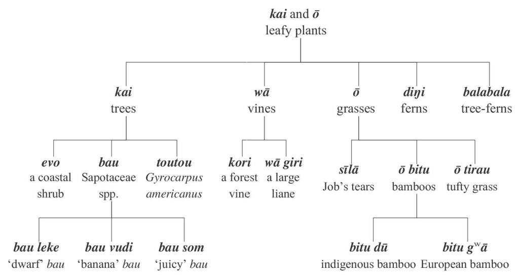

**Figure 3.2:** A partial ethnobotanical taxonomy of Wayan Fijian

**kai**

1. Wood
2. Generic for trees and shrubs (and occasionally low bushy plants)
3. Used in certain compounds as a generic for all plants.

**wā**

1. Generic for scrambling and climbing plants; creeper, vine.
2. Cord, rope, string.

**ō**

1. Generic term includes mostly non-bambusoid grasses and a few sedges and herbs.
2. Used as first element in compounds as a generic term for any leafy plant including bamboo, trees, reeds, and vines. Plants which are not *ō* in sense 2 include mosses, lichens and mushrooms.

**diŋi**

Generic for ferns, includes at least the: following two medium-sized terrestrial ferns: *Nephrolepis biserrata* (Davalliaceae) and *Sphaerostephanos invisus* (Thelypteridaceae).

**balabala**

Generic for tree ferns (Cythea species), sometimes extended to include other large ferns.

Wayan *kai* ‘tree, shrub’ encompasses about 200 named subtaxa which are again classified on the basis of shared morphological and ecological features. It is the names of these subtaxa which Wayan speakers tend to use when identifying particular plants (Gardner and Pawley 1992:10), and nearly all are folk generics. Generally the subtaxa of *kai* are the lowest-level of classification and denote a particular species within a ‘scientific’ classification. For example, *evo*, *māsei* and *toutou* (defined below, Pawley & Sayaba 2003) are all subtaxa of *kai* which are not further subclassified in Wayan.

**evo**

*Argusia argentea* (Boraginaceae). Large broad-leaved shrub of coastal sands, uncommon on Waya, young parts densely grey-silver hairy, small white flowers on curving branches, small black berries. Useful only for firewood.

**māsei**

*Pritchardia pacifica* (Arecaceae). A native fan-palm, cultivated for ornament around houses. The immature seeds are sometimes eaten by children.

**toutou**

*Gyrocarpus americanus* (Hernandiaceae). Tree of coastal slopes and rocky places inland, pale smooth bark, large oval or 5-lobed leaves with a rather strong bean-like odour, bunches of hanging 2-winged fruit. The soft wood is used for fires; it is good for carving, and formerly was used to make ulatoka (inshore fishing raft platforms). A medicine of some kind is made from bark, for treating internal organs.

There are also subtaxa of *kai* which are further subclassified into apparent folk specifics, as can be seen from the dictionary entries given below for *araro* and *doi* (Pawley & Sayaba 2003).

**araro**

*Premna* sp. or spp. (*Premna serratifolia*, *Premna protrusa*) (Verbenaceae). Small coastal tree with entire leaves. Hard wood, much used for posts.

**araro alewa**

*Premna serratifolia* (Verbenaceae). Small bushy tree, occasional in scrub near coast. Leaves opposite, rounded-oblong to pointed and heart-shaped, flowers smallish, green-white, small dark fleshy fruit with a hard 4-chambered stone.

**araro taŋwane**

*Premna protrusa*. A larger tree than *Premna serratifolia*, with flower parts more protruding, usually found inland. Hard wood, much used for posts.

**doi**

Generic for *Alphitonia* spp. (Rhamnaceae). Trees of open dryish forest.

**doi dū**

*Alphitonia zizyphoides*. Tree of open dryish forest, bark and leaves smelling of oil-of-wintergreen when crushed, leaves white below, small white flowers, purplish fruit capsules.

**doi drā**

*Alphitonia franguloides*. Uncommon tree of dryish slopes, leaves smaller and more pointed than those of *Alphitonia zizyphoides*.

The names for folk specifics tend to be binominals which include the generic followed by a modifier indicating some distinctive characteristic of the folk specific. For example, Wayan distinguishes four kinds of *bau* ‘Sapotaceae varieties’: *bau leke*, literally ‘dwarf bau’, denotes the smaller *Planchonella garberi* (Pouteria, cf. Wheatley 1992) species; *bau levu*, ‘big bau’ which presumably denotes larger species of Sapotaceae; *bau som*, where som means ‘to suck or eat juicy, soluble or soft, moist foods’, denotes the various Sapotaceae species which have milky juice; and *bau vudi*, ‘banana bau’ which denotes varieties with elongated (i.e. banana- like) fruit.

**bau**

Generic, includes species of *Burckella*, *Manilkara*, *Palaquium* and *Planchonella* (Sapotaceae). Wood of some of these trees is used for boats, chests and house posts. Applied to the following species growing on Waya:

1. *Burckella richii*. large tree of low- to middle-altitudes, fruit green, fleshy, cylindrical, 4cm long;
2. *Manilkara vitiensis*, smallish tree, often in exposed situations on coastal slopes;
3. *Palaquium fidjiense*. smallish uncommon tree of higher-altitude forest;
4. *Planchonella garberi* (Sapotaceae).
5. *Planchonella grayana*, a tree of coastal and inland forest, leaves larger and rounder than those of *Planchonella garberi*.

**bau leke**

*Planchonella garberi* (Sapotaceae). Occasional in mid-altitude forest.

**bau levu**

One or more species of Sapotaceae, application of name not clear.

**bau som**

Name applied to various (perhaps most or all) members of the Sapotaceae, in reference to their milky juice.

**bau vudi**

Name applied on mainland to members of Sapotaceae (spp. of *Burckella* and *Manilkara*), presumably because of their large and elongate fruits.

The *wā* ‘vine, creeper’ taxon includes upwards of fifty subtaxa, virtually all of which occur either optionally or obligatorily with the generic *wā* as a classifier, for example, *wā giri* or *giri* ‘*Entada phaseoloides*’ and *wā bitubitu* ‘Smilaceae species’ (Gardner & Pawley 1992: 9, 12, Pawley & Sayaba 2003). Subtaxa of *wā* form the lowest level of classification, and the majority denote a single species, as can be seen from the following dictionary definitions of *alu*, *kori* and *wā giri* (Pawley & Sayaba 2003).

**alu**

*Epipremnum pinnatum* (Araceae). Common forest climber, the young plant with simple oval leaves, creeping on ground, the climbing adult with stout stems and large deeply- cut leaves. Leaves provide a medicine for stomach-ache.

**kori**

*Mucuna gigantea* (Leguminosae). Forest vine, broad bean-like leaves, flowers green, curved, broad dark pods at first with golden-brown irritant hairs, the discoid reddish grey seeds found in the drift.

**wā giri**

*Entada phaseoloides* (Leguminosae). Large high-climbing liane of inland forest with huge leathery pods, the large discoid dark red-brown seeds common in the drift. Stems are used to tie thatching.

A small number of subtaxa of *wā* denote more than one species, but here too these sub taxa appear to be the lowest level of named classification, as with rautolu and wa bitubitu.

**rautolu**

Generic, includes various *wā* and shrub taxa with 3-partite leaves.

1. *Canavalia rosea*. Common vine of sandy foreshore, flowers pink-purple, pods about 10 x 2 cm, often wrinkled. Leaves said to have been used after childbirth in some way.
2. *Canavalia sericea*. Local on sandy foreshore, the leaves silver-hairy.
3. *Jasminum degeneri*.
4. (obsolete) *Melicope cucullata*.

**wā bitubitu**

Generic, includes two species of strong-stemmed vines.

1. *Smilax vitiensis* (Smilacaceae). Forest vine, stems strong, round, sometimes with a few prickles, leaves oval to heart-shaped, leathery, with a pair of tendrils at the stem, red to black 1-3-seeded berries hanging together from a dangling stalk. Used for binding rafters and making fish-traps.
2. *Geitonoplesium cymosum* (Smilacaceae). Slender but strong vine of forest understorey, small orange fruit with black glossy seeds.

The Wayan term *ō* is somewhat harder to describe. Typical *ō*-type plants are non-bambusoid grasses and some sedges and herbs. However, *ō* can also occur as the initial element in names of reeds (*ō sina*) and bamboo (*ō bitu*), suggesting that *ō* includes not only grasses and herbs, but also woody-stemmed plants that are grass-like. There are about fifty subtaxa of grasses, herbs, reeds and bamboos that are denoted by the life-form *ō* (Gardner & Pawley 1992: 12), and most of these subtaxa appear to be the lowest level of classification, whether denoting a single species as with *ō ðaŋiðaŋi* and *ō tirau*, or denoting several species as with *sīlā*.

**ō ðaŋiðaŋi**

*Cymbopogon coloratus*. Lemon grass. Stout tussocky uncommon grass of dry hill-sides. Leaves smell of lemon, and are used to make tea, and for padding under house mats.

**ō tirau**

*Imperata cylindrica* (Gramineae). Occasional grass of hillsides, tufts to about knee-height, flower heads silky, cylindrical. Used for thatching.

**sīlā**

Generic, includes two large-seeded grass,es (Gramineae).

1. *Coix lacryma-jobi*. Job’s tears. Coarse grass, fertile parts with tear-shaped blueish bony structures that enclose the true seeds.
2. *Zea mays*. Maize or sweet corn. Occasionally cultivated.

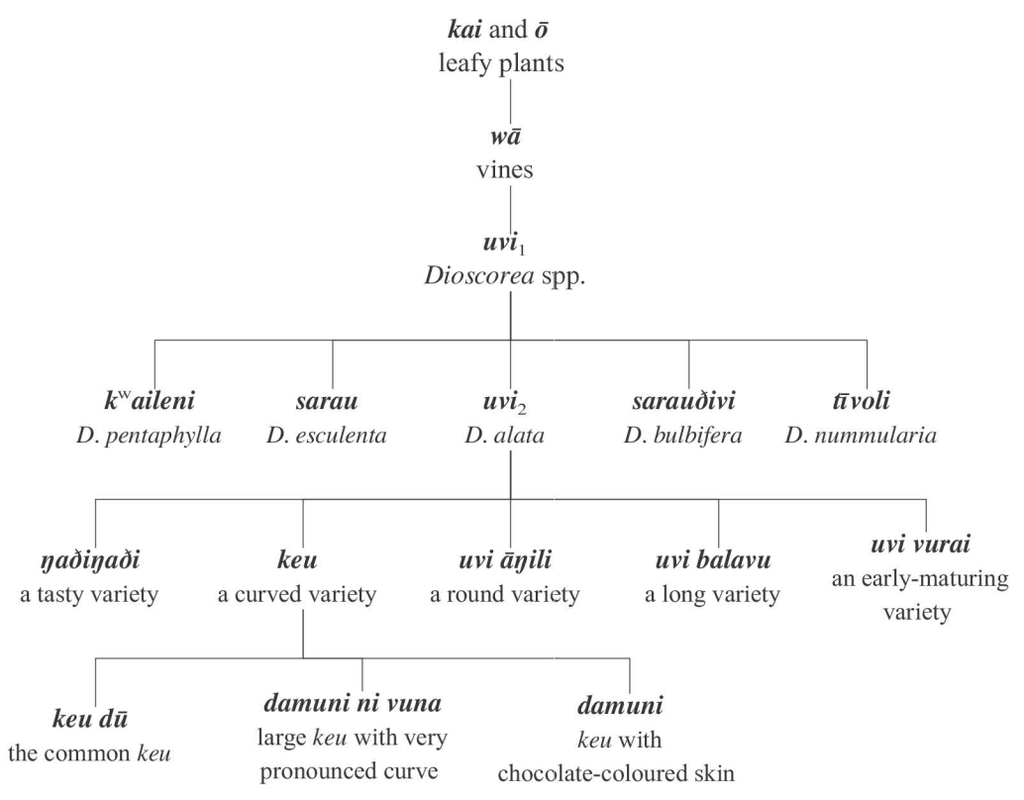

**Figure 3.3:** A partial plant taxonomy of Wayan Fijian, showing taxonomic depth of some cultivated food plants

As can be seen from Figure 3.2, the taxonomy of wild plants in Wayan Fijian is quite shallow, including four named levels. The naming of cultivated food plants, however, comprises a deeper taxonomy. Thus while labels for particular species, and more commonly genera, form the lowest level of classification among wild plants, for cultivated food plants there will often be a number of named varieties below the folk species level. In fact, as shown by Figure 3.3, if cultivated food plants are incorporated in the Wayan ethnobotanical classification, the taxonomy includes at least six levels. Figure 3.3 shows this with a selection of the named types of yams. Yams are considered to be part of the *wā* ‘vine’ taxon, one group of which, the *Dioscorea* species are denoted by the generic term *uvi*. More specifically *uvi* denotes *Dioscorea alata* yams and encompasses a large number of named varieties, some of which are themselves further subclassified. Thus *keu* ‘a variety of *uvi* with a curved tuber’ has three varieites: *damuni* ‘with chocolate-coloured skin’; *damuni ni vuna* ‘large, with very pronounced curve’ and *keu dū* ‘the common variety’.

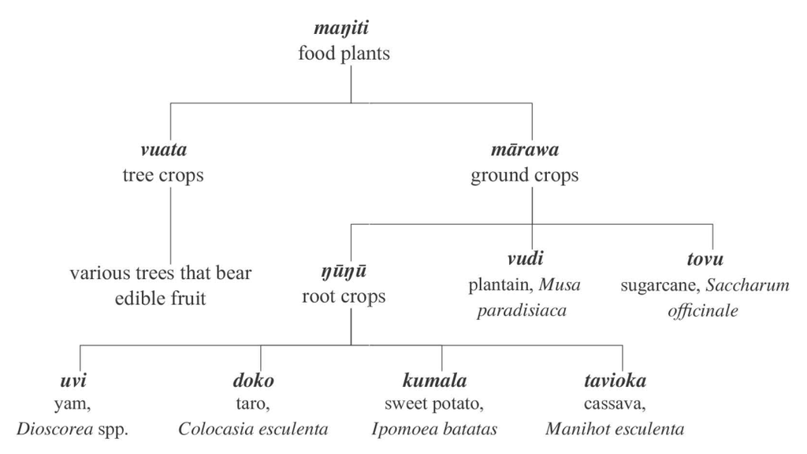

**Figure 3.4:** A partial classification of foods in Wayan Fijian

Gardner & Pawley (1992: 15) also note other categories of plants in Wayan which cut across the taxonomy presented above. For example, while in one sense *uvi* ‘*Dioscorea* species of yams’ would be categorised as *wā* ‘vines’, they can also be classified as *marawa* ‘ground crops, food plants other than trees’. The system of classification that includes *marawa* ‘ground crops’ is partially shown in Figure 3.4. *Marawa* ‘ground crops’ contrasts with *vuata* ‘tree crops, trees that bear edible fruit’, and encompasses not only root crops such as yam, taro and sweet potato, but also other non-tree food crops such as melons, maize, sugarcane and bananas (Gardner & Pawley 1992: 15), and thus is not a category that fits within the taxonomy presented in Figure 3.2. This latter taxonomy is based primarily on the use and cultural status of the plants, in contrast to the former taxonomy that is based mostly on the morphological and ecological characteristics of the plants.

### 3.2. Kwara’ae

Kwa’ioloa & Burt (2001) present a classification and description of *rū bulao kī* ‘growing things’ in Kwara’ae, and this classification is shown schematically in Figure 3.5. Their classification is as much to present a catalogue of Kwara’ae plant names and uses as to describe the Kwara’ae folk botanical taxonomy, and so descriptive names have been given to groups of plants that are recognised as similar by Kwara’ae speakers, but that did not necessarily form labelled taxa originally. In developing Figure 3.5 only those labels from Kwa’ioloa and Burt which denote traditionally overt or covert categories have been included. Terms that were traditionally used by Kwara’ae speakers are in bold and those that have been developed for Kwa’ioloa and Burt’s book but appear to reflect originally covert categories are in plain text. As can be seen the Kwara’ae folk taxonomy is quite shallow with only four or five levels.

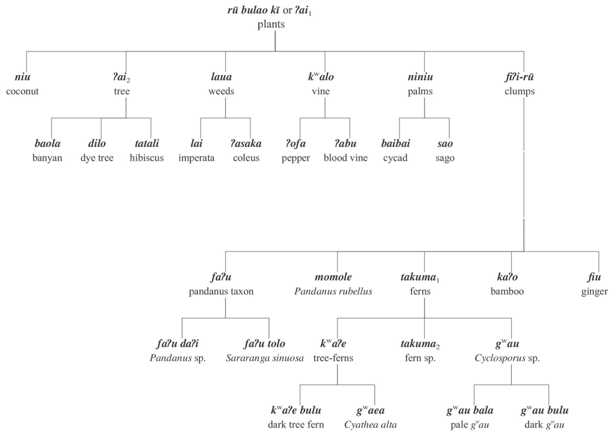

**Figure 3.5:** A partial ethnobotanical taxonomy of Kwara’ae

The nominal use of *bulao* ‘to grow’ in *rū bulao kī* ‘growing things’ is a way to refer to the kingdom category of all plants. Most growing things can also be denoted by *ʔai* ‘tree’, although more commonly *ʔai* has a narrower meaning. It is not clear if Kwara’ae speakers traditionally recognised a category of all plants or if this category results from the need for a way to talk of all plants when working on Kwai’oloa and Burt’s book. Burt notes that the classification of plants by Kwara’ae speakers is mainly for ‘pragmatic and utilitarian purposes’ and that not all categories are mutually exclusive, but rather the categories overlap in various ways (Kwa’ioloa & Burt 2001: 16). Kwara’ae speakers appear to classify the majority of *rū bulao ki* ‘growing things’ into three categories: *ʔai* ‘tree’, *fiʔi-rū* ‘clumps’ and *kʷalo* ‘vines’. The distinguishing characteristics of *ʔai* plants are a hard trunk and a branching growth structure. Kwara’ae *ʔai* can also be used more broadly to denote palms, soft-cored trees (eg. pawpaw), cordyline shrubs, gingers and ferns, which are not considered *ʔai* ‘tree’ in the narrow sense of the word. *fiʔi-rū* ‘clumps’ is the descriptive term, comprising the classifier, *fiʔi* and the noun *rū* ‘things’, to denote plants that grow as a cluster of stems. Thus *fiʔi-rū* ‘clumps’ encompasses plants like gingers, bamboos and ferns. The term *fiʔi-rū* ‘clumps’ is listed as a possible life-form taxon in Figure 3.5, although it is not entirely clear if this is a traditional Kwara’ae taxon. However, Burt notes that this category of plants includes those which can be indicated by the classifier *fiʔi*, and so traditionally *fiʔi-rū* ‘clumps’ may have been a covert category. The term *kʷalo* ‘vines’ denotes plants with a climbing or creeping growth structure, that is those plants used as cordage, a secondary meaning of *kʷalo*. However, *kʷalo* does not include the vines of edible tubers which are referred to as *kʷala*. While they appear to form the basis of botanical classification in Kwara’ae, these three life-form taxa are not mutually exclusive but rather seem to be labelled groups along a continuum of morphological characteristics, such that *ʔai* ‘tree’ normally referring to plants with single hard stems and branches may sometimes be used to refer to cordyline shrubs, which under other circumstances may be referred to *fiʔi-rū* ‘clumps’ .

Palms do not fit within this three-way classification at all. As noted, palms may be referred to as *ʔai*, but only in its broad sense that denotes all plants, and not in its more narrow sense. Burt (Kwa’ioloa and Burt 2001: 17) describes palms as a covert category. Kwara’ae speakers generally refer to palms by the individual names, but recognise and readily acknowledge the similarities amongst them. Palms may be described as *rū ki gasiʔi rebani* ‘things we tear into flat pieces’, denoting their shared use for slatting and battens. This is a function that characterises palms, but is not restricted to them. Kwa’ioloa and Burt (2001:186) use the word *niniu* to label the category of palms, describing it as denoting kinds of trees (ʔai) that are similar in being tall and erect with leaves that emerge from a stave or mid-rib. Members of the *niniu* taxon are not eaten or burnt as fuel, but are important in making platforms and walls as well as battens for thatching, and their fronds are used for making brooms. The term *niniu*, an apparent reduplication of *niu* ‘coconut, *Cocos nucifera*’ suggests that this category may be based on resemblance of form and use of palms to *niu* ‘coconut’. However, *niu* ‘coconut’ itself is not referred to as *niniu*, probably because of its common occurrence and importance (Kwa’ioloa and Burt 2001: 17).

The other small category of plants that does not fit within any of the three major categories is *laua* ‘weeds’. It denotes small plants that ‘can (and often should) be ’pulled up’ when they grow in places like gardens’ (Kwa’ioloa and Burt 2001: 17). However, the term *laua* can also be used to refer to seedlings or saplings.

Kwara’ae *ʔai* ‘tree’ is a large category with over 200 named types described in Kwa’ioloa and Burt (2001: 102-181). They classify *ʔai* into three groups: (i) *ʔai doe kī* ‘big trees’; (ii) *ʔai ne?e kesi doe liu goʔo kī* ‘trees which don’t get very big’; and (iii) *ʔai ne?e tiʔitiʔi goʔo kī* ‘trees which are just small’. These descriptive labels and the groups they represent appear to have been established for the convenience of Kwa’ioloa and Burt’s (2001) book, and it is unclear if they are in common usage amongst Kwara’ae speakers. Thus they are not listed in Figure 3.5. The majority of the named types of *ʔai* appear to denote single scientific species and form the lowest level of classification. However, a few are further subclassified. For example, *lami-lami* ‘archidendron, *Archidendron oblongum*’ denotes two named varieties of *Archidendron oblongum* that appear to be distinguished on the basis of morphological characteristics. The small tree, *ʔalaʔala* ‘*Codiaeum variegatum*’ also encompasses a number of named varieties (Kwa’ioloa and Burt 2001:134, 175).

**lamilami**

A very big tree, archidendron, *Archidendron oblongum*.

**etana lamilami**

First archidendron. A big tree with brown trunk, wide leaves and a yellow flower that has an acute sme:ll, which grows in the lowlands and beside big bodies of water. Used for making canoes, cooking houses and for fuel.

**ruana lamilami**

Second archidendron. A very big tree with buttress roots and a whiteish trunk that grows in swamps and mangroves. Used for building houses and for fuel.

**alaʔala**

Croton, *Codiaeum variegatum* species. A small tree that grows wild in the lowlands and by the sea and is planted around homes. Fronds used for decorating houses and people.

**ʔalaʔala marako**

Green *ʔalaʔala*, with really green leaves

**ʔalaʔala sako**

Yellow *ʔalaʔala*, with yellow leaves.

**ʔalaʔala meo**

Red *ʔalaʔala*, with red leaves

**ʔalaʔala fiʔirodo**

Getting-dark *ʔalaʔala*, with red and darkish leaves

**ʔalaʔala ogamu**

Wants-to-break *ʔalaʔala*, with a leaf that has breaking points.

Kwa’ioloa & Burt (2001: 193-219) divide *fiʔi-rū* ‘clumps’ into a number of groups. The group *fiʔi-rū ne?e boeboena ka ofi fafia faʔina kī* ‘clumps with leaf-tubes sheathing the stem’ encompasses plants like gingers, bananas and alpinas. That is, leafy plants with soft-core stems that are sheathed with leaves. The group *fiʔi-rū ne?e kasiruʔa kī* ‘clumps which are sectioned’ is the descriptive term used for plants like bamboos and reeds that have stems with nodes and can thus be cut into internode sections. These two categories are not listed in Figure 3.5 as they represent groups of plants that can be seen as similar in form and use, but are apparently not categories traditionally recognised by Kwara’ae speakers. Kwa’ioloa & Burt (2001: 207 -213) use the term *takuma* to denote all ferns. Strictly speaking *takuma* refers to *Diplazium proliferum* and other ferns are referred to by their individual names. However, *takuma* would also be used to refer to a bundle of different edible ferns that included *Diplazium proliferum*, suggesting the traditional presence of a covert category at least. Thus *takuma* as a category denotes *Diplazium proliferum*, an important fern, and other plants considered similar in terms of morphological characteristics, namely a short dark bole, long curled-over leaves and the lack of flowers or fruit. Kwa’ioloa and Burt (2001:212) also include in this category *kʷaʔe*, the generic term for tree-ferns, which also denotes the ‘proper’ or important tree-fern *Cyathea lunulata*. Tree-ferns are plants with leaves like ferns but trunks like trees. The young leaf-shoots are eaten and the trunks used for building. The term *kʷaʔe* encompasses a number of different named varieties.

The term *kʷalo* ‘vines’ appears to be a smaller taxon than either *ʔai* ‘trees’ or *fiʔi-rū* ‘clumps’, with only 38 subtaxa listed by Kwa’ioloa and Burt. A few of these are further subclassified, but the majority are terminal taxa. It is not clear where grasses and grass-like plants fit into the Kwara’ae classification, as they are not mentioned by Kwa’ioloa and Burt, although one grass, *lai* ‘Imperata conferta’ is classified as *laua* ‘weeds’ .

### 3.3. Arosi

The determination of ethnobotanical taxonomies in other modern Oceanic societies has been based on dictionaries and lexicons and so the conclusions are less certain. However, such dictionary searches do suggest that a number of other Oceanic languages, including Nduke (Meso-Melanesian, Scales n.d.), Arosi (SE Solomonic, Fox 1978) and Samoan (Polynesian, Milner 1966), have systems of ethnobotanical classification that are not greatly different from that of Kwara’ae and Wayan Fijian. Figure 3.6 shows schematically an Arosi taxonomy that can be constructed from plant names in Fox’s dictionary.[^4]

Again, Arosi appears to have no form which denotes all plants in contrast to non-plants. There is a general term which denotes uncultivated plants, namely *hara* ‘a wild plant that grows of itself, is not planted by man’. However, a contrasting term for cultivated plants was not found. Arosi has at least four major life-form categories of plants which seem to be based on morphological characteristics similar to those defining the life-form categories in Wayan Fijian.

**ʔai**

A tree or plant having stems and branches; not used of fern, cycad, sago palm, coconut etc., but used of small plants, eg. balsam.

**rari**

Any herb or shrub which has no main stem, as flax.

**warawaro**

Vines.

**kaariŋa**

Mushroom, fungus.

The important morphological characteristic of *ʔai*-type plants is apparently the presence of a main stem and branching structure, but Fox (1978) notes that *ʔai* can also be used ‘loosely’ to refer to coconut palms and tree-ferns, plants which lack branching structure but do have a distinct main stem. In contrast to Wayan, *ʔai* in Arosi does not in its primary meaning include palms. The term *rari* denotes herbs and shrubs that lack a main stem, and since ‘as flax’ is included in the definition, it is possible that this taxon may also include grass-like plants. However, as I did not find an Arosi term that appeared to denote a life-form taxon encompassing grasses, in Figure 3.6 various names of grasses have been represented as primary taxa. Plant types that could be labelled ferns and epiphytes in English also do not appear to be included in any of the other four life-form categories and have been represented as primary taxa.

The subtaxa of the four major life-form categories generally form the lowest level within the classification. However, of the 200 or more plant names which are encompassed by the *ʔai* taxa, there are at least five which are further subclassified. For example,

**hahe (mahe)**

A shrub, sweet-smelling and sacred, planted in hera, burial grounds, and used to decorate armlets; long glossy leaves, four sepals, petals and stamens in the white flowers, *Euodia hortensis*.

**hahe bora**

with dark leaves

**hahe mora**

with pale leaves

**hahe rei**

with very small leaves

**boboro**

a species of hahe

**ʔoʔo**

A species of tree

**ʔoʔomaradaro**

variety used for gong making

**ʔoʔorawaraha**

another variety

**ʔoʔoriʔi**

a variety used for making outrigger canoes

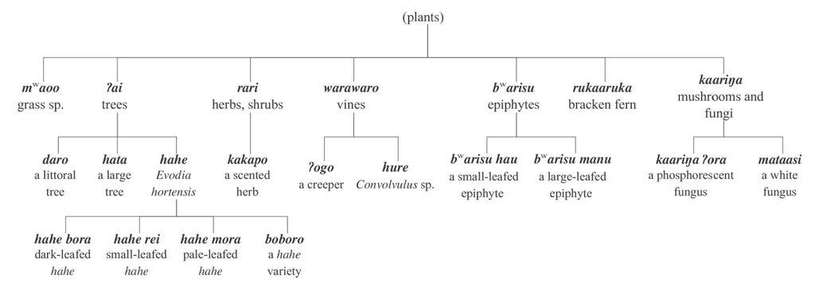

**Figure 3.6:** Arosi ethnobotanical classification

Arosi *warawaro* ‘vines’ is another category that includes a large number of sub taxa, with between 50 and 100 named items occurring in the dictionary. However, all of the subtaxa of *warawaro* ‘vines’ form the lowest level of classification. The same is true of the sub taxa of *rari* ‘herbs and shrubs’ and *kaariŋa* ‘mushrooms’.

### 3.4. Nduke

Nduke speakers distinguish seven primary taxa of plants. The term *ɣae*, primarily used to denote ‘trees’ can also be used to refer to all plants (Scales n.d.).

**ɣae**

A general name for any kind of tree, bamboo, tree-ferns and other tall plants (except grass) that have woody stems.

**veve**

A general name for vines and creepers.

**heheu**

A general name for all kinds of grass (mostly Poaceae family). Also used to refer to dicot herbs.

**lulumutu**

A general name for green algae that grows inside concrete tanks etc. and moss that grows on trees.

**roɣa**

A general name for plants which grow as brambles or thickets.

**havoro**

Flower, also used as the general name for flowering plants such as orchids.

**pureke**

A general name for mushrooms. Often refers to a kind of edible mushroom that grows on rotting sago palm trunks in swamps.

The category *ɣae* ‘tree’ is the largest in Nduke with over 200 subtaxa. Many of these are terminal taxa, but some are further subclassified. Unusually amongst Oceanic languages bamboos and tree-ferns are classified as *ɣae* ‘tree’ in Nduke. Veve ‘vines and creepers’ consists of about 20 subtaxa and *heheu* ‘grasses and dicot herbs’ over 10, all of which are terminal taxa. *Roɣa*, a ‘general term for plants which grow as brambles and thickets,’ refers more to areas where the vegetation is characterised by thicket-type growth, than particular types of plants that are characterised by thicket-type growth (Ian Scales, pers.comm.).

### 3.5. Samoan

**lāʔau**

Plant, tree

**ʔoliʔolī**

General name given to large ferns

**pupuvao**

Tall grass, weeds

**mutia**

Grass

**fue**

General name given to creepers and lianas

**taliŋa**

Name given to several types of fungus, including Jew’s-ear

**limu**

General name given to mosses, lichens, algae, and seaweeds

## 4. Botanical taxa in Proto Oceanic

A number of the primary botanical taxa that are shared by many modern Oceanic languages have cognate labels and are reconstructable for POc. Clearly reconstructable for POc are the following five terms that denoted broad categories of plants, apparently based on particular morphological characteristics.

**kayu**

Tree or shrub -generic name for plants with woody stems and branches, probably not including palms or tree-ferns (§4.2).

**waRoc**

Generic term for vines and creepers, plants with creeping or climbing growth structure (§4.4).

**pali[sj]i**

Generic term for grasses and other ‘grass-like’ plants (§4.5).

**limut, *lumut**

Generic term for mosses, algae and seaweeds (§4.6).

**taliŋa**

Generic term for mushrooms and fleshy fungi (§4.7).

### 4.1. Plant

A term denoting all plants is not reconstructable for POc. A number of modern Oceanic languages do have a general term for plants, but these terms appear to be post-POc innovations. The list below gives the general terms for ‘plant’ in a number of languages, but none are cognate. In NE Ambae and Anejom these gene:ral terms for ‘plants’ are nominalisations of verbal terms. For example, NE Ambae rivurivu ‘plant’ is a reduplicated form of the transitive verb *rivu* ‘to plant s.t.’, and Anejom *nita-awañ* is formed from the verb *awañ* ‘to plant’ with the instrumental prefix.

| Adm | Lou | *koe* | ‘plant (N)’ |
| --- | --- | --- | --- |
| NNG | Poeng | *kinkiniŋ* | ‘(all) growing things; grass, tree’ |
| NNG | Sissano-Arop | *oraman* | ‘plants (generic)’ |
| SES | Bugotu | *jou* | ‘to plant, a plant’ |
| NCV | Ambae | *rivurivu* | ‘plant (N)’ |
| SV | Anejom̃ | *nita-awañ* | ‘plant, s.t. planted or to be planted’ |
| Mic | Trukese | *pətəwər* | ‘plant (general term), vegetation (uncultivated); tree, bush, shrub, fern, grass’ |

A Proto Micronesian form *fadoka ‘planted thing, cultivated plants’ is reconstructable (Bender et al 2003:24), but appears to be restricted to meaning something that has been planted rather than all plants. This form looks to be a nominalisation of a Proto Micronesian verbal *fadoki ‘to plant’.[^5]

| **PMic** |  | *fadoka | ‘planted thing, cultivated plants’ |
| --- | --- | --- | --- |
| Mic | Kiribatese | *aroka* | ‘planted thing, cultivated plants’ |
| Mic | Trukese | *fɔtā-* | (from *fɔto-* ‘planting’ and a noun-forming suffix) |
| Mic | Woleaian | *jato* | ‘plant (N)’ |
| Mic | Carolinian | *jɔto* | ‘generic term for plants’ |
| Mic | Ulithian | *fa-faxu* | ‘plant (N)’ |

| **PMic** |  | *fadok(-i) | ‘to plant (s.t.)’ |
| --- | --- | --- | --- |
| Mic | Kosraean | *yuki* | ‘to plant (s.t.)’ |
| Mic | Mokilese | *pɔtok* | ‘to work at planting, to set in the ground (vT)’ |
| Mic | Trukese | *jɔtuki* | ‘to plant (s.t.)’ |
| Mic | Carolinian | *jɔtoxi* | ‘to plant (s.t.)’ |
| Mic | Woleaian | *jatoxi* | ‘to plant (s.t.)’ |

If POc speakers did have a category that included all plants, then it appears to have been covert. In this respect POc would have been like most modern Oceanic languages which lack a general term ‘plant’. Gardner and Pawley (1992:8-9) note that in Wayan the category ‘plant’ is best considered covert as no term has ‘plant’ as its central meaning. Wayan *kai* ‘generic for trees and shrubs (and occasionally low bushy plants)’ is sometimes used as a generic for all plants. It is difficult to assert the presence or absence of a covert kingdom category in POc. From meanings of reflexes in the daughter languages, it is not clear that the general meaning of ‘plants’ can be reconstructed as a secondary meaning of terms denoting other more specific categories of plants.

### 4.2. Tree

The most stable primary taxon label, in that it is reflected most widely amongst the modern languages is *kayu, the general term for trees and other plants with woody stems and branches. While some languages, like Bing, appear to have retained the original vowel-glide-vowel sequence, the majority have simplified it in some way. These changes appear to have occurred reasonably late in the development of this form, since there are closely related languages that show different types of changes. For example, *kayu is reflected as *au* in Mono, but as *ɣae* in Nduke, two NW Solomonic languages, and as *kau* in Bauan and *kai* in Wayan, two Fijian languages.

| **PMP** |  | *kayu | ‘tree, wood, timber’ (Dempwolff 1938) |
| --- | --- | --- | --- |
| **POc** |  | *kayu | ‘tree or shrub: generic name for plants with woody stems and branches, probably not including palms or tree-ferns; wood, stick’ |
| Adm | Loniu | *ke* | ‘tree, wood’ |
| Adm | Titan | *kei* | ‘firewood’ |
| NNG | Lukep (Pono) | *kai* | ‘tree, wood’ |
| NNG | Mangap | *ke* | ‘wood, tree (generic)’ |
| NNG | Bing | *ayuw* | ‘firewood, fallen tree ready for firewood’ |
| NNG | Takia | *ai* | ‘tree (generic), wood, firewood, plant’ |
| NNG | Manam | *ʔai* | ‘tree, stick’ |
| NNG | Sissano-Arop | *ai* | ‘tree, stick, wood’ |
| PT | Motu | *au* | ‘tree, finewood’ |
| PT | Iduna | *ai* | ‘tree, plant, wood, fire, light’ |
| PT | Muyuw | *kay* | ‘tree’ |
| PT | Misima | *ai* | ‘tree, wood’ |
| MM | Patpatar | *ai-* | ‘tree species, followed by name of species’ |
| MM | Mono | *au* | ‘tree’ |
| MM | Nduke | *ɣae* | ‘general name for any kind of tree, bamboo, tree-ferns and other tall plants (except grass) that have woody stems’ |
| SES | Gela | *ɣai* | ‘branching plant, shrub or tree (i.e. balsam, croton and banyan are all *ɣai*, but not palm or coconut); wood, timber; firewood.’ |
| SES | Bugotu | *ɣai-* | ‘tree, shaft of spear’ |
| SES | Kwaio | *ʔai* | ‘branch, tree, stick; woody plant (shrub, tree)’ |
| SES | Arosi | *ʔai* | ‘tree or plant with stem and branches; not used of a fern cycad, sago palm, coconut etc, but used of small plants, eg. balsam.’ |
| NCV | Ambae | *kai* | ‘tree, wood’ |
| NCV | Paamese | *āi* | ‘tree, wood, stick’ |
| NCV | Nguna | *na-kau* | ‘tree’ |
| SV | Anejom̃ | *inɣai* | ‘tree, wood, often used for relatively small bushes’ |
| NCal | Xârâcùù | *kʷãã* | ‘wood, tree (general term)’ |
| Mic | Kiribatese | *kai* | ‘wood (in general), tree, plant, stick’ |
| Mic | Trukese | *eyi-* | ‘stick, tree, pole’ (only used in compounds) |
| Mic | Ulithian | *-xæy* | ‘counting classifier for trees’ |
| Fij | Rotuman | *ʔai* | ‘tree, plant; wood, timber, piece of wood’ |
| Fij | Bauan | *kau* | ‘tree, piece of wood, stick’ |
| Fij | Kadavu | *kaðu* | ‘tree’ |
| Fij | Wayan | *kai* | ‘wood; generic for trees and shrubs, and occasionally also low bushy plants; used in certain compounds as generic for all plants; piece of wood, stick’ |
| Pn | Tongan | *kau* | ‘stalk, stem’ |
| Pn | Tikopia | *kau* | ‘stalk, stem supporting bunch of fruit’ |
| Pn | Samoan | *ʔau* | ‘stalk; shaft, axle; handle’ |
| Pn | Hawaiian | *ʔau* | ‘handle, staff, stem, bone of lower arm or leg’ |

Many reflexes of *kayu have additional senses besides ‘tree or shrub’, namely ‘wood, timber’, ‘stick’ and ‘firewood’. For the POc term both ‘tree or shrub, general name for plants with woody stems and branches’ and ‘wood, timber’ are reconstructed as they seem to be the best supported by the modern reflexes. The descriptions in a number of modern languages suggest that woodiness and a main stem, along with branching growth structure are likely to have been the salient characteristics of *kayu plants in POc.

In Polynesian languages there has been a semantic shift and the reflexes of *kayu have the meaning of stem or stalk. The Proto Polynesian term for tree or woody plant was **raʔakau*. This form was a compound of reflexes of POc *raqan ‘branch’ and *kayu ‘tree’, supporting the idea that the presence of a main stem and branching growth structure were the salient features of this category.

| **PPn** |  | *raʔakau | ‘generic term for tree or woody plant; wood, timber; generic for all plants’ (POLLEX) |
| --- | --- | --- | --- |
| Pn | Niuean | *akau* | ‘wood, tree’ |
| Pn | Tongan | *ʔakau* | ‘tree, plant; wood’ |
| Pn | East Futunan | *laʔakau* | ‘tree, bush, shrub; wood, plant’ |
| Pn | Rennellese | *gaʔakau* | ‘tree, bush, shrub, log, stick’ |
| Pn | Tikopia | *rakau* | ‘generic term for member of vegetable kingdom, usually woody plant, including tree, shrub, herb, but not applied to root vegetable or grass’ |
| Pn | Samoan | *lāʔau* | ‘plant, tree’ |
| Pn | Hawaiian | *lāʔau* | ‘tree, plant, wood, timber’ |
| Pn | Māori | *rākau* | ‘tree; wood, timber; stick’ |

### 4.3. Palms

Were palms considered *kayu? For the majority of reflexes of POc *kayu it is not clear from the dictionary definitions whether palms are included within the category. For languages where the definitions are explicit about the status of palms, in some cases palms are included and in others not. For example, in Gela and Arosi (SE Solomonic) the categories denoted by *ɣai* and *ʔai*, respectively, do not include palms. In Wayan Fijian, on the other hand, *kai* does appear to encompass palms, with a number of different palms, including *māsei* ‘fan palm (*Pritchardia pacifica*)’, *niu* ‘coconut (*Cocos nucifera*)’ and *soŋa* ‘palm used for thatching (*Sagus vitiensis*, Arecaceae)’ defined as part of the *kai* taxon in Pawley and Sayaba (2003). In a few languages palms appear to form labelled categories of their own. Thus Anejom *nakʷai* is the generic term for palms, though excluding coconuts (Lynch 2001a: 173). In Samoan *niu* is a ‘general name for palms, especially the coconut palm’ (Milner 1966: 156-7). Also in Tongan there is evidence that *niu* ‘coconut tree or fruit’ can be used to refer to palms more generally since it optionally occurs as part of the name for fan palm (*niu piu* or *piu* ‘fan palm, *Eupritchardia pacifica*’, Churchward 1959). Burt describes palms as a covert category in Kwara’ae (Kwa’ioloa & Burt 2001: 17). That is, while Kwara’ae speakers recognise and acknowledge the similarities amongst palms, they do not name such a category.[^6]

A term denoting palms as a category does not appear to be reconstructable for POc, and it seems likely that palms were considered primary taxa within the system. But was ‘palm’ a covert category for POc speakers, as it is today for Kwara’ae speakers? There is some evidence for this in that terms for different parts of palms, such as *bala(p,b)a(q) ‘palm branch’ and *[pa]paq[a-] ‘frond of palm’ are reconstructable, suggesting the recognition of a category of plants with similar morphological characteristics (Malcolm Ross pers. comm.). It is of course possible that the variation in the treatment of palms amongst the modern languages refiectes variation in POc. Thus it could be that palms were considered *kayu ‘tree, shrub’ by some speakers of POc and not others and in some circumstances and not others. Such a situation would not be unexpected in the light of studies on ethnobotanical classifications.

### 4.4. Vine, creeper

The final consonant of the POc form is reconstructed as *c rather than *s, as although the internal Oceanic evidence cannot disambiguate the choice between *c and *s, the external evidence points to *c.

| **PMP** |  | *waRej | ‘vine, creeper’ (ACD) |
| --- | --- | --- | --- |
| **POc** |  | *waRoc | ‘generic term for vines and creepers, plants with creeping or climbing growth structure; string, rope’ |
| Adm | Wuvulu | *wao* | ‘rope, vein, tendon’ |
| NNG | Bing | *war* | ‘vine (generic)’ |
| NNG | Gedaged | *wal̥* | ‘vine, liana’ |
| PT | Iduna | *waloga-* | ‘vein’ |
| PT | Misima | *wal* | ‘stem (of mustard vine)’ |
| PT | Motu | *varovaro* | ‘vines of all kinds’ |
| MM | Nakanai | *ualo* | ‘cord, thread’ |
| MM | Roviana | *aroso* | ‘general name for vines and creepers’ |
| MM | Marovo | *adoso* | ‘vine, creeping or climbing, general term; climbing vines of *Calamus* types (lawyer cane)’ |
| SES | Gela | *alo* | ‘a creeper, string’ |
| SES | Bugotu | *aðo* | ‘rope, cord, creeper’ |
| SES | Tolo | *alo* | ‘generic name for vines; rope, string’ |
| SES | Lau | *kʷalo* | ‘a vine of yam, sweet potato etc’ |
| SES | Kwaio | *kʷalo* | ‘vine, string, rope’ |
| SES | ’Are’are | *waro* | ‘a liana, string, rope’ |
| SES | Sa’a | *walo* | ‘a creeper, rope, string, line, vine’ |
| SES | Arosi | *waro* | ‘a piece of string, twine; prefix to names of creepers’ |
| SES | Arosi | *waro-waro* | ‘vines’ |
| SV | Anejom̃ | *inwau* | ‘vine; rope (traditional), string; sinew, tendon, vein’ (also occurs as initial element in a number of names of vine species.) |
| Fij | Bauan | *wā* | ‘a vine, creeper of any kind’ (also occurs as initial element in a number of names of vine species) |
| Fij | Wayan | *wā* | ‘generic for scrambling and climbing plants; creeper, vine’ |

### 4.5. Grass

POc *pali[s,j]i appears to have been the generic for plants lacking a main stem and with narrow-leafed foliage, that is grasses and grass-like plants.

| **PMP** |  | *bali(j,z)i | ‘(type of ?) grass’ (ACD) |
| --- | --- | --- | --- |
| **POc** |  | *pali[s,j]i | ‘generic term for grasses and other grass-like plants’ (Grace 1961: *palisi) |
| Adm | Nauna | *pelic* | ‘grass’ |
| Adm | Pak | *penit* | ‘grass’ |
| NNG | Poeng | *paili* | ‘grass’ |
| NNG | Tami | *ijili* | ‘grass’ |
| MM | Lihir | *palic* | ‘grass’ |
| MM | Ramoaaina | *wali* | ‘grass’ |
| MM | Halia | *halisi* | ‘grass’ |
| SES | Kwaio | *falisi* | ‘grassy undergrowth (generic); yam harvest’ |
| SES | ’Are’are | *harisi* | ‘grass, small clover’ |
| SES | Sa’a | *ha-halisi* | ‘grass’ |
| SES | Ulawa | *hälisi* | ‘grass, onion (late use)’ |
| NCV | Mota | *valis* | ‘a tall coarse grass; in recent use grass generally and onions’ |
| NCV | Mwotlap | *vlih* | ‘grass, turf (Gramineae), *Thuarea involuta*’ (*na-plih*) |
| NCV | Wusi | *palihi* | ‘grass’ |
| NCV | Morouas | *βalisi* | ‘grass’ |
| SV | Sye | *(novl)ovsi* | ‘buffalo grass (*Stenotaphrum secundatum*)’ (cf. *novol* ‘kind of plant; initial element for plant names including a grass, a fern and two tree-ferns’) |
| SV | Southwest Tanna | *nə-vhilək* | ‘a kind of grass’[^8] |
| SV | Anejom̃ | *ne-pces* | ‘a kind of grass’ |
| Mic | Trukese | *fetiɾi* | ‘grass’ |
| Mic | Carolinian | *fitili, fetili* | ‘grass’ |
| Mic | Woleaian | *fatili* | ‘grass (*Thuarea involuta* or *Stenotaphrum*)’ |
| Pn | Samoan | *falī* | ‘kind of grass(? *Scirpodendron* species)’[^9] |

The semantic scope of *pali[s,j]i in POc is not totally clear. Poeng, Kwaio, Chuukese and Carolinian support the reconstruction of this term as a generic for grasses, but there are also several languages where reflexes of *pali[s,j]i denote particular, but different, types of grass, including Mota, Sye, Anejom, Woleaian and Samoan. Thus while a generic meaning is reconstructed for POc *pali[s,j]i, it needs to be noted that it is not so well-supported as the reconstruction of other life-form taxa.

On the basis of modern languages it seems likely that POc would have had a primary taxon that included at least grasses and/or herbs. In Wayan Fijian *ō* usually denotes non-bambusoid grasses, but does occur as the initial element in the names of reeds (*ō sina*) and bamboos (*ō bitu*). In Nduke heheu is glossed as ‘grasses and dicot herbs’ and appears to be restricted to soft grasses, bamboos being part of the *ɣae* ‘tree’ taxon. In other languages, like Gumawana, Lau and Mokilese, apparently generic terms for grass are also glossed weeds. Arosi, on the other hand, does not appear to have a generic term for grasses, although *rari* ‘herbs and shrubs with no main stem’ may encompass grasses as well. Such a category would also appear to fit within the system of the other, better-supported, higher-order taxa of POc. At this stage *pali[s,j]i appears to be the most likely label for such a category, but further data and research may lead to different conclusions.

### 4.6. Moss, algae, seaweed

There also appears to have been variation in the POc term that denoted mosses, algae and seaweeds, such that *lumut and *limut are both reconstructable. This life-form taxa seems to have been characterised by the morphological characteristic of ‘leaflessness’, thus including mosses, lichens and algae, and extended to other plants which share with algae the ecological characteristics of growing underwater. That both forms were present in POc and many lower level proto-languages can be seen from the way reflexes of each occur in quite closely related languages. For example, Tinputz and Roviana are both NW Solomonic languages, and Tinputz has a form *nimus* reflecting POc *limut and Roviana a form *lumu-lumutu*, reflecting POc *lumut. The same is true of the Micronesian languages, where Woleaian has a form *ɾumʷu* and Mokilese a form *limʷ*. It is also possible that there were fully-reduplicated variants of these forms in POc, thus *limulimut and *lumulumut, since languages from a range of subgroups have reduplicated reflexes.

Evidence from non-Oceanic languages suggests that *lumut may have been the older form meaning ‘moss’. For example, Indonesian *lumut* ‘1. moss, lichen, bryophyte; 2. algae’, Ilokano *lumot* ‘moss, a slippery river seaweed; fine freshwater algae’, Tagalog *lumot* ‘moss’. Ilokano and Tagalog also have forms *limu* ‘seaweed’ without the final *-t*, and it is possible that pre-POc *lumut ‘moss’ and *limu ‘seaweed’ were conflated in POc.

| **POc** |  | *lumut | ‘generic term for mosses, algaes and seaweeds’ (Capell 1943) |
| --- | --- | --- | --- |
| Adm | Lou | *lum* | ‘seaweed; weed/grass growing in sea water’ |
| NNG | Manam | *lumta* | ‘moss’ |
| NNG | Mangap | *lum* | ‘algae, green slimy growth on trees, stones etc under water’ |
| PT | Iduna | *nunu(bʷana)* | ‘moss, slime on ground’ (cf. *bʷana* ‘phlegm’) |
| PT | Muyuw | *numt* | ‘moss’ |
| MM | Nakanai | *lumu* | ‘moss, incl. *Psilotum nudum*, *Microsorum* species’ |
| MM | Nduke | *lu-lumutu* | ‘a general name for green algae that grows inside concrete tanks etc. and moss that grows on trees’ |
| MM | Roviana | *lumu-lumutu* | ‘a variety of moss; a marine alga’ |
| SES | Gela | *lumu* | ‘moss, weeds on keel’ |
| SES | Bugotu | *lumu(sa)* | ‘moss’ |
| SES | Tolo | *lumu-lumu* | ‘moss’ |
| SES | Longgu | *lumu-lumu* | ‘moss’ |
| SES | Kwaio | *lumu* | ‘moss’ |
| SES | Lau | *lu-lumu* | ‘moss, lichen growth on ship’s keel’ |
| SES | ’Are’are | *rumu* | ‘seaweed, moss on trees, used in ceremonial purification’ |
| SES | Sa’a | *lumu(te)* | ‘moss’ |
| NCV | Mota | *lumu(ta)* | ‘moss’ |
| NCV | Ambae | *lumu(si)* | ‘moss’ |
| NCV | Tamambo | *lum-lum* | ‘moss, lichen; k.o. seaweed’ |
| NCV | Vurës | *lum-lum* | ‘moss, seaweed, algae’ (cf. *mölumlum* ‘soft, slow’) |
| NCV | Lewo | *lum-lum* | ‘slime in sea’ |
| NCV | Nguna | *na-lumu-lumu* | ‘moss, sponge, algae’ |
| NCV | Paamese | *lum-lum* | ‘moss, slime, seaweed’ |
| SV | Anejom̃ | *ne-lomʷ* | ‘moss, hanging algae’ |
| SV | Lenakel | *ləmus* | ‘moss, algae, seaweed’ |
| Mic | Woleaian | *ɾumʷu* | ‘moss, seaweed; to be covered with moss, having moss’ |
| Mic | Carolinian | *lūmʷ* | ‘moss; seaweed variety that grows luxuriantly on rocks and sunken vessels and that breaks off and washes onto shore’ |
| Mic | Trukese | *ɾūmʷ* | ‘seaweed, moss; sea algae, scum’ |
| Fij | Rotuman | *lumu* | ‘seaweed, moss’ |

| **POc** |  | *limut | ‘generic term for mosses, algaes and seaweeds’ (Biggs 1965: *timu) |
| --- | --- | --- | --- |
| PT | Misima | *nimút* | ‘moss’ |
| MM | Tolai | *limut* | [N] ‘green colour or mossy growth on a canoe which has been standing in the water, seaweed, slime’; [ADJ] ‘green, blue, moss-green, colour of moss’ |
| MM | Ramoaaina | *limut* | ‘seaweed, slime; blue’ |
| MM | Kara (East) | *limut* | ‘tree moss’ |
| MM | Sursurunga | *milut* | ‘moss’ (metathesis) |
| MM | Tinputz | *nimus* | ‘moss’ |
| NCV | Namakir | *limi-lim* | ‘seaweed, sea moss’ |
| SV | Southwest Tanna | *ləmus* | ‘moss, algae’ |
| Mic | Mokilese | *limʷ* | ‘seaweed, sponge, moss’ |
| Mic | Marshallese | *limɯ-limɯ* | ‘moss’ |
| Fij | Bauan | *lumi* | ‘moss, adhering to a rock or a boat; a kind of edible seaweed’ |
| Fij | Wayan | *lume-lume* | ‘algae, green slime which grows on reefs and keels of boats, and in rivers and ponds’ |
| Pn | Tongan | *limu* | ‘seaweed, moss, lichen’ (cf. *limu tahi* ‘seaweed’, *limu ʔuta* ‘moss, lichen’) |
| Pn | Samoan | *limu* | ‘general name given to mosses, lichens, algae, and seaweeds’ (Also initial element in a number of plant names.) |
| Pn | Hawaiian | *limu* | ‘a general name for all kinds of plants living under water, both fresh and salt, also algae living in any damp place in air, as on ground, on rocks and on other plants; also mosses, liverworts, lichen… |
| Pn | Māori | *rimu, rimu-rimu* | ‘seaweed; moss, mildew’ |

### 4.7. Mushrooms, fungi

In a number of modern Oceanic languages the life-form term for mushrooms and other fleshy fungi is homophonous with the bodypart term ‘ear’. For example, in Wayan Fijian *taliŋa* denotes fleshy fungi such as mushrooms and bracket fungi as well as ‘ear’. The polysemy of ‘mushroom’ and ‘ear’ is also found with non-cognate forms in a number of Oceanic languages, such that innovative terms can be seen to have both meanings. For example, in NE Ambae *gʷero* has both the meaning of ‘ear’ and of ‘mushroom’, and the same is true for the Nakanai term *gavusa* ‘(a) mushroom (Agaricaceae); ear’. The cognate set for POc *taliŋa below supports the reconstruction of this same polysemy. That the ‘mushroom’ meaning is not a post-POc innovation is supported by the fact that reflexes of *taliŋa occur in a number of languages with ‘mushroom’ meanings, but not with the ‘ear’ meaning. Of the languages in the cognate set below, the four North New Guinea languages, Nakanai, Gela and Tolo are all languages where the reflex of *taliŋa no longer has the meaning of ‘ear’, but has retained the ‘mushroom’ meaning. In Anejom *in-ticŋa-*, the reflex of *taliŋa, retains only the ‘ear’ meaning, but the historical presence of the ‘mushroom’ meaning is indicated by the occurrence of *in-ticŋa-* in a number of compounds referring to mushrooms. In Rotuman, Bauan Fijian, a number of Polynesian and Micronesian languages terms for mushrooms literally mean ‘ear of spirit/ghost’. The Rotuman form *faliŋa ne ʔatua* and the Tikopian form *tariŋa ŋa a tua* look to be cognate compounds, but in other languages the second part of the compound does not appear to be cognate.

| **POc** |  | *taliŋa | ‘generic term for mushrooms and fleshy fungi; ear’ (ACD) |
| --- | --- | --- | --- |
| NNG | Poeng | *taliŋ* | ‘mushroom’ |
| NNG | Dami | *talik* | ‘fungus, mushroom’ |
| NNG | Hote | *taliŋ* | ‘mushroom’ |
| NNG | Sissano-Arop | *tɛlin* | ‘mushrooms, edible’ |
| MM | Nakanai | *taliga* | ‘a small edible fungus, Lensites’ |
| SES | Gela | *taliŋa* | ‘fungus, mushroom on *mbiluma* tree’ |
| SES | Tolo | *taliŋe* | ‘generic name for mushrooms’ |
| SES | Kwaio | *aliŋa* | ‘mushroom’ |
| SES | Sa’a | *ʔäliŋe* | ‘mushroom, large fungus’ |
| NCV | Paamese | *raliŋen asu* | ‘kind of fungus which grows on dry wood’ |
| SV | Anejom̃ | *inticŋa-* | ‘ear; initial element in a number of compounds denoting mushrooms’ |
| SV | Anejom̃ | *inticŋa-nɣai* | ‘mushroom (arboreal)’ (cf. *in-ɣai* ‘tree’) |
| SV | Anejom̃ | *inticŋa-pʷohtan* | ‘mushroom (terrestrial)’ |
| SV | Anejom̃ | *inticŋa-numu* | ‘kind of edible mushroom’ (cf. *numu* ‘fish, marine creature’) |
| Mic | Kiribatese | *taniŋaniba* | ‘mushroom-like fungus growing on tree trunks. Myxomycetes: slime fungus’ |
| Mic | Mortlockese | *sæliŋananu* | ‘mushroom (lit. ear of ghost)’ |
| Mic | Woleaian | *taɾiŋeripaç* | ‘mushroom’ (underlying form: *taliŋali-paça*) |
| Mic | Satawalese | *saliŋanipac̣* | ‘kind of toadstool’ |
| Fij | Bauan | *daliŋa ni kalou* | ‘fungus (lit: ear of spirit)’ |
| Fij | Wayan | *taliŋa* | ‘generic, includes various kinds of fleshy fungi, e.g. mushrooms, bracket fungi’ |
| Fij | Rotuman | *faliŋa* | ‘ear; toadstool or fungus’ (Also *faliŋa ne ʔatua* ‘ear of dead/ghost’) |
| Pn | Tongan | *taliŋeliŋa* | ‘fungus’ |
| Pn | Tikopia | *tariŋa (ŋa atua)* | ‘ears of spirits; traditional name applied to a tree fungus (unidentified)’ |
| Pn | Samoan | *taliŋa* | ‘Name given to several types of fungus, including Jew’s-ear’ |
| Pn | Māori | *tariŋa (rakau)* | ‘a fungus’ |
| Pn | Māori | *tariŋa (o tiakiwai)* | ‘Jew’s ear fungus, Auricularia auricula-judea’ (Also called *tariŋa kuri* (dog), *tariŋa hakeke*) |

### 4.8. Other terms

The five primary taxa reconstructed here do not appear to have encompassed all plants that would have been known to POc speakers, or indeed, for which terms can be reconstructed. The contrast between POc *kayu ‘plants with woody stems and branches’, *pali[s,j]i ‘grass- like plants’ and *waRoc ‘plants with creeping or climbing growth structure’ leaves open the question of how non-woody leafy plants, such as alpinias or gingers and the like, would have been classified by a POc speaker. In Kwara’ae *fiʔi-rū* is the descriptive category that encompasses plants which grow as a cluster of stems, including plants like ginger with leaf-tubes sheathing the stem, plants with sectioned stems like bamboo, plants like ferns and pandanus (Kwa’ioloa and Burt 2001: 193-219). Hawaiian appears to have a similar category, *pū* which denotes plants with a ‘cluster of several stalks, as of banana, pandanus, kava; clump, as of sugarcane’ (Pukui & Elbert 1971: 317). In Marovo (Meso-Melanesian), there is a general term *rokoroko* for leafy shrubs which may have a similar range, and in Anejom the term *nathancai*, literally ‘young tree’ is used to denote saplings and plants smaller than trees, including ferns and crotons (Lynch 2001a: 189). However, as far as I am aware there does not appear to be a general term for non-woody leafy plants which can be reconstructed for POc.

Ferns and tree-ferns are also plants which do not appear to fit into any of the life-form categories reconstructed for POc. In Kwara’ae there is a general term for tree-ferns, *kʷaʔe*, and a number of other Oceanic languages also have general terms that denote tree-ferns:

| Mic | Kosraean | *po* | ‘kind of plant: tree fern’ |
| --- | --- | --- | --- |
| Fij | Wayan | *balabala* | ‘generic for tree ferns (*Cyathea* spp.), sometimes extended to include other large ferns, such as *Pteris tripartita*’; ‘*Cyathea lunulata* (Cyatheaceae)’; ‘*Cyathea* sp., perhaps *Cyathea propinqua*… |
| Pn | Hawaiian | *ʔamaʔu* | ‘all species of an endemic genus of ferns (*Sadleria*), with trunk more or less evident’ |

From this it seems possible that tree-ferns formed a higher-order taxon in POc, but no term appears to be reconstructable to back up such a hypothesis.

In Wayan *balabala* ‘tree-ferns’ contrasts with another primary taxon *diŋi*, a generic for at least two types of terrestrial ferns. In Kwara’ae *takuma* ‘*Diplazium proliferum*’ is sometimes used to denote a collection of edible ferns that includes *Diplazium proliferum* Woodsiaceae, though more commonly ferns are referred to by their individual names. In other languages, such as Iduna, Kosraean, Samoan and Hawaiian there are terms that may denote ferns more generally, but it is not clear from the dictionary definitions. A generic term for ferns does not appear to be reconstructable for POc, and it seems likely that the individual names of ferns were considered to be primary taxa.

| PT | Iduna | *maiwa* | ‘(edible) ferns’ |
| --- | --- | --- | --- |
| Mic | Kosraean | *fa* | ‘a kind of plant: fern’ |
| Mic | Mokilese | *pʷɔ* | ‘fern’ |
| Fij | Wayan | *diŋi* | ‘generic that includes at least the following two medium-sized terrestrial ferns: *Nephrolepis biserrata* (Davalliaceae), ladder fern, locally common in open mid-altitude forest; *Sphaerostephanos inv… |
| Pn | Samoan | *ʔoliʔolī* | ‘(i) general name given to large ferns; (ii) tree-fern (Also phila species)’ |
| Pn | Hawaiian | *kupukupu* | ‘general name for ferns on a single stem’ (also name for sword fern) |

POc *qauR appears to have been the general term for bamboos, with a number of more specific terms also reconstructable (ch.13, §3.1 ). Kwa’ioloa and Burt (2001) use the descriptive term *fiʔi-rū* ‘clumps’ or ‘plants which grow as several stems’, or more narrowly *fiʔi-rū ne?e kasiruʔa kī* ‘clumps which are sectioned’ to represent a group of plants including bamboos which have similar growth patterns and uses. In Kwara’ae *kaʔo* ‘bamboo, *Nastus obtusus*’ is called ‘proper bamboo’, but this term does not appear to be used as a generic for all bamboos (outside of Kwa’ioloa and Burt’s book). In Wayan Fijian, bamboos and reeds are included in the *ō* ‘grasses’ taxon. But there is no clear evidence that bamboos were considered part of any larger category that can be reconstructed for POc.

It is unclear how pandanus were classified by POc speakers. In Kwara’ae, pandanus are considered to be part of the larger category of *fiʔi-rū* ‘clumps’, whereas in Wayan Fijian pandanus are considered part of the *kai* ‘trees and shrubs’ taxon. In ch.11, §2.5 Ross reconstructs a number of terms for different types of pandanus and suggests that *padran ‘coastal pandanus, *Pandanus tectorius*’ was also the generic term for pandanus. This is supported most strongly by Carolinian where the reflex of *padran, *fāṣ* is the generic term for pandanus (Jackson & Marck 1991: 59). Thus it seems likely that pandanus in POc were either: (a) usually known by their individual names and were unaffiliated primary taxa; or (b) were classified as a distinct taxon known as *padran ‘pandanus (generic)’.

A number of modern Oceanic languages have a category of plants that is glossed as ‘weeds’, as can be seen from the following list. In a number of languages, including Poeng, Gela and Kwara’ae this category appears to denote plants growing unwanted in garden plots. However, these categories do not have cognate labels. POc *talu(n) ‘old garden, fallow land, land returning to secondary growth’ (vol.1, ch.5, §3.2) may have denoted land with this type of vegetation, but a term for the vegetation itself does not appear to be reconstructable.

| NNG | Mapos Buang | *vavɔ̄ŋ* | ‘scrub, brush, weeds’ |
| --- | --- | --- | --- |
| NNG | Labu | *wahe* | ‘weeds’ |
| NNG | Poeng | *kilanna* | ‘weed; growing in old garden spot’ |
| NNG | Takia | *ud* | ‘weed, wild grass (generic)’ |
| NNG | Mangap | *momotia* | ‘weed (N)’ |
| PT | Iduna | *boya* | ‘smalll weeds’ |
| PT | Gumawana | *nauna* | ‘weeds, grass’ |
| PT | Misima | *mʷawín* | ‘grass; weeds, to have weeds’ |
| MM | Ramoaaina | *bual* | ‘full of weeds’ |
| MM | Ramoaaina | *palep* | ‘weeds, rubbish; in a plantation’ |
| MM | Teop | *subui* | ‘weeds’ |
| SES | Gela | *makiri* | ‘smalll weeds in a garden’ |
| SES | Lau | *ʔoroʔoro* | ‘weeds, grass, anything small growing up’ |
| SES | Lau | *murua* | ‘weeds and grass’ |
| SES | Kwaio | *fufulu* | ‘weed, grass’ |
| SES | Kwara’ae | *laua* | ‘weeds, plants that can (and often should) be pulled out when they grow in places like gardens; seedlings, saplings’ |
| Mic | Mokilese | *tipʷtipʷ* | ‘grass, weeds; overgrown with grass or weeds, littered (with objects)’ |
| Mic | Trukese | *wəɾɨŋŋaw* | ‘useless plant, weed’ (cf. *wəɾɨ* ‘bush, vegetation generally’, *ŋŋaw* ‘bad, ugly, unfitting, unsuitable’) |
| Pn | Māori | *otaota* | ‘herbs in general, weeds, litter’ |

## 5. Conclusions

Figure 3.7 shows schematically a partial ethnobotanical classification for POc based on the reconstruction of higher-order taxa presented here and plant names presented in chapters 5-13. The kingdom rank category of ‘plant’ had no name in POc, and it is unclear if it was an implicit category or not. POc appears to have had five major life-form taxa: *kayu ‘tree or shrub, generic name for plants with woody stems and branches, probably not including palms or tree-ferns’; *waRoc ‘general term for vines and creepers, plants with creeping or climbing growth structure’; *pali[s,j]i ‘generic term for grasses and possibly also sedges and other grass-like plants’; *limut or *lumut ‘generic term for mosses, algaes and seaweeds’; and *taliŋa ‘generic term for mushrooms and fleshy fungi’.

Ross’s reconstructions of plant names in chapters 5-13 suggest that the subtaxa of these life-form categories tended to be terminal taxa. However, as folk generics tend to be more stable than specifics (Pawley this volume), it is not surprising that Ross is unable to reconstruct many terms for specifics. Rather, it is likely that POc behaved like contemporary languages in similar environmental and cultural contexts and had named folk taxa within many of the folk generics that Ross reconstructs.

In chapters 5-13 of this volume Ross reconstructs POc names for over 80 plants which were most probably considered subtaxa of the *kayu ‘tree, shrub’ category. The majority of these reconstructions, like *tuRi-tuRi ‘candlenut tree, *Aleurites moluccana*’, *putun ‘*Barringtonia asiatica*’, *aRu ‘a shore tree, *Casuarina equisetifolia*’, *paRu ‘a small shore tree, *Hibiscus tiliaceus*’, *qatita ‘the putty nut, *Parinarium laurinum*’ and *quRis ‘Polynesian plum, *Spondias dulcis*’, denote a single ‘scientific’ species. A few reconstructions, such as *kalaqabusi ‘a shrub, *Acalypha* species’ and *kapika ‘Malay apple and rose apple, Eugenia species’ denote two or more ‘scientific’ species, but still appear to have formed the lowest level within the classification. It is only with a few types of *kayu ‘tree, shrub’ that Ross found evidence to reconstruct a folk generic that denoted several different species and terms for folk species within the generic category. For example, the POc term *[ka]ŋaRi was polysemous, denoting both *Canarium* species in general and *Canarium indicum* in particular. A second POc term *qalip ‘canarium almond, *Canarium* species’ may have denoted a separate species (ch.ll, §2.1). There are also a few types of *kayu ‘tree, shrub’ for which Ross can reconstruct more than one POc term, such as *ñoñum and *kurat both denoting the Indian Mulberry tree (*Morinda citrifolia*), which may reflect cases where POc speakers distinguished by name different varieties of a single ‘scientific’ species, but often the difference between these terms in POc is not entirely clear.

As expected from the comparative evidence, POc speakers appear to have had more levels within the classification of food plants than with non-food plants. Thus, although it appears that for most plants folk generics denoting a particular ‘scientific’ species formed the lowest level of classification, for some food plants POc speakers appear to have used folk generics to refer to a cluster of similar species and other more specific terms to denote single species. This was seen above with *[ka]ŋaRi ‘canarium almond, *Canarium indicum*; *Canarium* species in general’, and can be seen in Figure 3.7 with regards to types of yams. Alongside the terms for specific species of yams, POc speakers also appear to have used *qupi ‘greater yam, *Dioscorea alata*; yam (generic)’ to denote yams in general (ch.9, §2.1). The fine grade distinctions made in the naming and classification of food plants in POc can perhaps best be seen in the reconstructions of different types of edible *pudi ‘bananas’ (ch.9, §3), and several different growth stages for *niuR ‘coconut (generic)’ (ch.12, §3). It is also likely that, like Wayan Fijian speakers, POc speakers had other systems of classifying plants, such as in terms of food categories. For example, Ross (ch.10, §2.1) reconstructs a term *wasa which denoted *Abelmoschus manihot*, but also appears to have referred to the general category of ‘edible greens’.

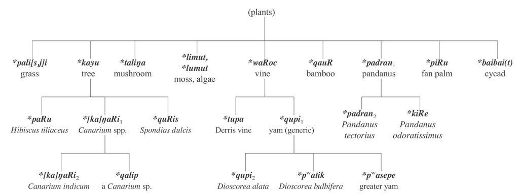

**Figure 3.7:** Partial Proto Oceanic ethnobotanical classification

The form *qauR ‘bamboos (generic)’ (ch.13, §3.1) denoted an additional life-form taxon, and *padran ‘coastal pandanus, *Pandanus tectorius*’ (ch.11, §2.5.1) may have also been used as a generic for all pandanus and thus been a life-form taxon. Palms may have formed a covert category, but it seems likely that they were referred to by their individual names and were unaffiliated to any other primary taxa. Ferns and tree-ferns also appear to have been unaffiliated taxa.

## Notes

[^1]: Thanks to Ian Scales for his help with describing the Nduke ethnobotanical classification and to Andrew Pawley for his detailed comments on earlier versions of this chapter, including help with the description of the Wayan Fijian system of classifying plants. Thanks also to Malcolm Ross for comments on earlier versions of this chapter. This paper has also benefited from the comments and suggestions of various people at the Oceanic conference in 2004 where an earlier version of the paper was presented.
[^2]: Berlin (1992: 190-194) presents both linguistic and behavioural evidence which can be used to determine the presence of covert kingdom rank categories.
[^3]: Randall (1976) argues that taxonomic tree hierarchies are probably not stored directly in the memory, but rather when necessary people can recall the perceptual characteristics of classes of flora and fauna to be used for different purposes, including gardening, foraging, naming plants and creating classification schema. If this is indeed the case, then a reason for changes in the meaning and scope of higher-order taxa within a classification may also be the result of changes in speakers’ views of what fits within a taxon each time it is used for a particular purpose.
[^4]: It is not clear from the dictionary definitions which other plants would be classified as *rari*.
[^5]: Osmond (1998: 132) reconstructs POc *asok ‘plant in holes in the ground’, along with a Proto Western Oceanic form *pasok-i- ‘to plant sth (tubers etc)’ that looks to be a form derived with the causative prefix *pa-. The Micronesian forms below are likely cognates of Proto Western Oceanic *pasok-i-, suggesting the reconstruction of *pasok-i- ‘to plant something’ for POc.
[^6]: To solve the problem of explicitly describing such a covert category in their classification and description of plants in Kwara’ae, Kwa’ioloa and Burt (2001: 17, 186) label palms as *niniu* ‘kinds of trees that are similar in being tall and erect and that are used for platforming and walling and for battens for thatching’, but this does not appear to be a conventional Kwara’ae usage.
[^7]: A third meaning, ‘vein’ is found in reflexes from a number of subgroups (Adm, NNG, PT, NCV, SV, Mic). Similar meanings are also found with some cognates in non-Oceanic Austronesian languages, such as Simalur *olor* ‘root, vein, tendon’ (Blust ACD).
[^8]: SW Tanna *nə-vhilək* ‘grass’ leads Lynch (2001 c: 246) to reconstruct Proto Southern Vanuatu *na-(p,v)alijiy, suggesting that the POc form was *pali[s,j]ik with a final *-k. However, there is no other evidence for POc *-k, and so I do not reconstruct it.
[^9]: The loss of POc *s in Samoan is irregular.
[^10]: One language, Simalur (WMP), reflects Proto Malayo-Polynesian *j, suggesting POc *c (Blust ACD) .